# Some Stats and R Facts

Data Justice Academy 2022

## Hypothesis testing and p-values

Let’s say we believe a coin is fair and lands heads 50% of the time.

We flip it 20 times and get 18 heads. That’s 90%.

If the coin was really fair, what is the probability of getting 18 or more heads?

The answer is about 0.0002. That’s a *p-value*.

That’s a small probability and leads us to reject the belief that the coin is fair.

## Hypothesis testing and p-values

What we just described is an example of a *hypothesis test*.

This can be performed for other statistics, such as a difference in means.

The *null hypothesis* is usually something like no effect, 0, or “no difference in means”.

We collect data, calculate our statistic, and then calculate the probability of getting the statistic we obtained (or something more extreme) if the null hypothesis was true.

When you see a p-value, think “probability of the data, or more extreme data, assuming a null hypothesis was true.”

## The Normal Distribution

The Normal Distribution is a curve that looks like a bell. Here’s a picture.

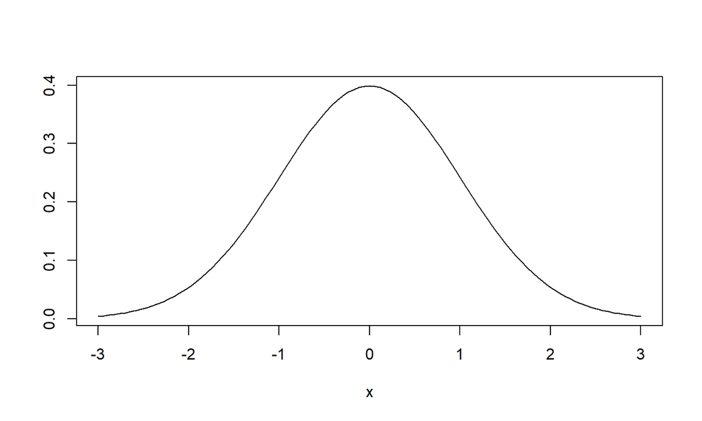

## The Normal Distribution

The mean is the top of the hump (red line). It’s the center of the curve. The standard deviation is the *inflection point*, where the curve goes from *concave down* to *concave up* (blue lines). It sort of measures the spread of the curve. Below we see the mean is 0 and the standard deviation is 1.

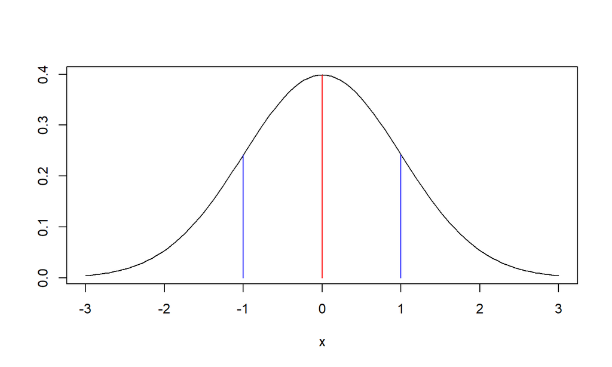

## The Normal Distribution

The mean and standard deviation are like dials or controls on a machine. Changing the mean moves the curve *left and right*. Changing the standard deviation changes the *spread* of the curve.

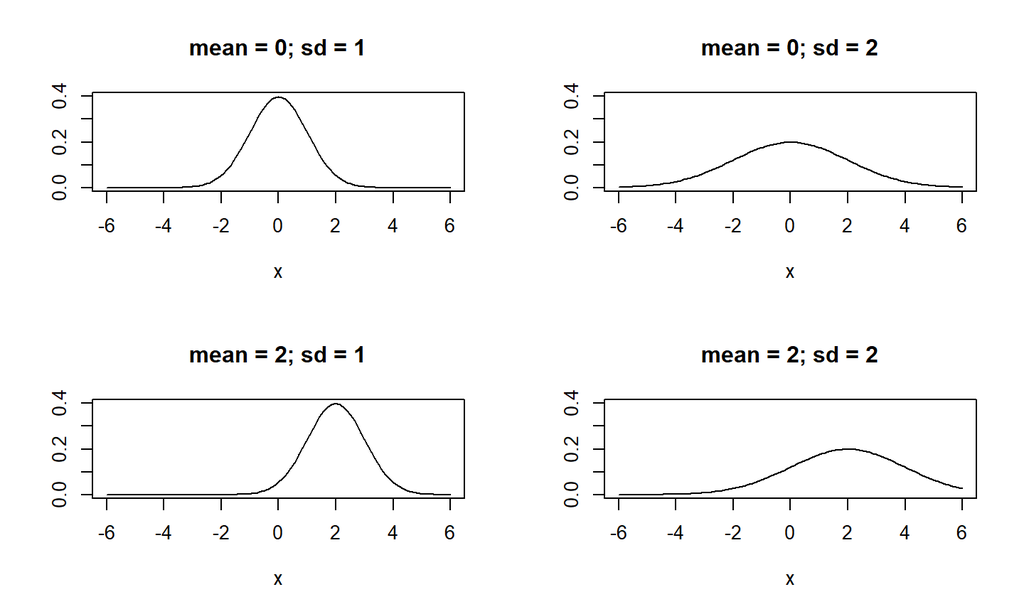

## The Normal Distribution

Since the mean and standard deviation completely determine the shape of the curve, we call them *parameters*. Statisticians use the Greek symbols \(\mu\) (mu) to represent the mean and \(\sigma\) (sigma) to represent the standard deviation.

Here’s the formula to draw the line from the Normal distribution [Wikipedia article](https://en.wikipedia.org/wiki/Normal_distribution). Fortunately, unless you teach a statistics class, you don’t need to remember it.

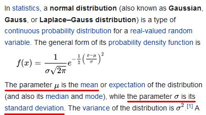

## The Normal Distribution

Calling the Normal distribution a *probability distribution* means the area under the curve is equal to 1, or 100%.

## Example

Take a look at this histogram of the heights of 250 randomly sampled US males. Most people are between 65 and 75 inches tall. Does the shape look familiar?

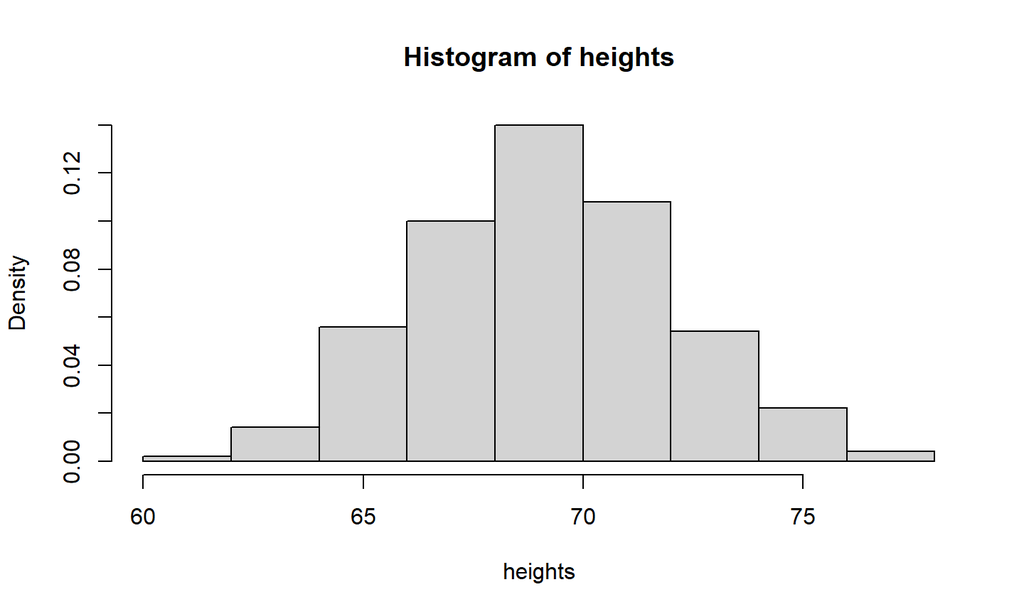

## Example

If we take the mean and standard deviation of our data sample, we can use those values as parameters in a Normal distribution and draw a smooth curve to *approximate* the distribution.

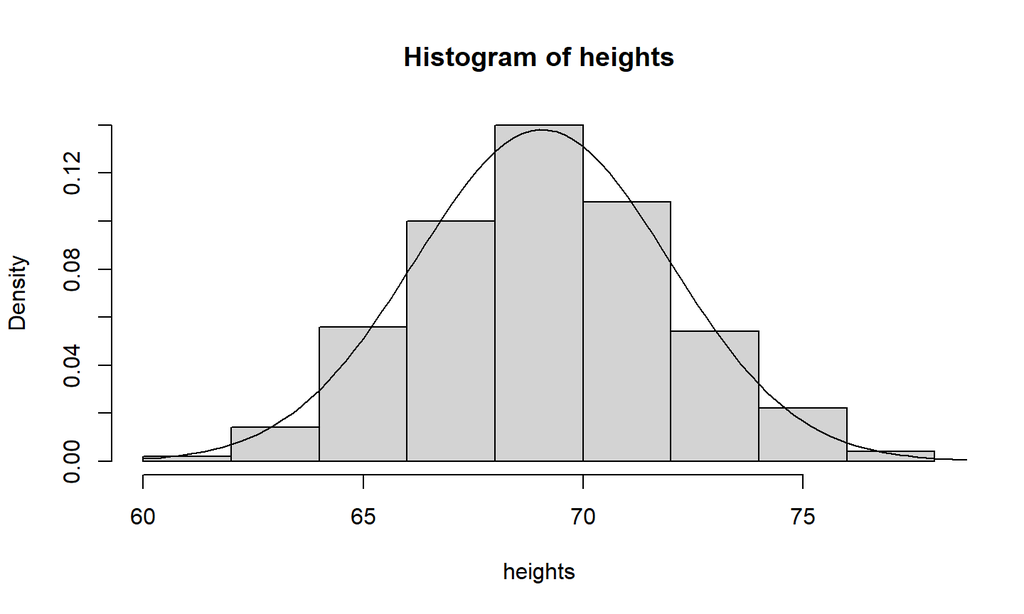

## Using the Normal distribution

Now we can use the Normal distribution to answer questions such as “what is the probability a randomly selected US male is taller than 6 feet 4 inches (76 inches)?” That’s the area under the curve to the right of 76 inches, the area below colored blue.

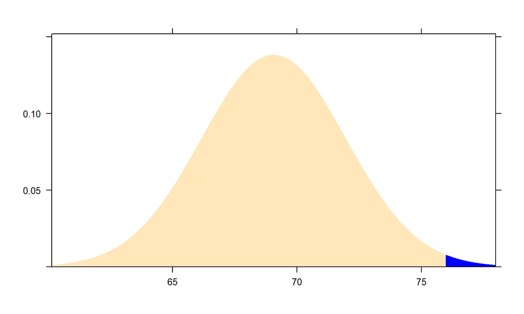

## Using the Normal distribution

R provides the `pnorm()` function to find area under the Normal curve. By default it finds area to the *left* of the value you give it. To go to the right, specify `lower.tail = FALSE`. Notice we use the `mean()` and `sd()` functions to find the mean and standard deviation of our data.

```r
pnorm(76, mean = mean(heights), sd = sd(heights), lower.tail = FALSE)
```

```
## [1] 0.008172683
```

0.008 rounds to about 0.01, or 0.01 \(\times\) 100 = 1%. It appears there’s about a 1% chance (1 in 100) that a randomly selected US male will be taller than 6 feet 4 inches.

## Simulating data

I didn’t really sample 250 US males and measure their heights. Instead I randomly sampled values from a Normal distribution with mean 69 inches and standard deviation 3 inches. I did that in R using the `rnorm()` function as follows. (The optional `set.seed(1)` code ensures you and I generate the same “random” data. Change the 1 to another positive integer and you’ll get another random set of data.)

```r
set.seed(1)
heights <- rnorm(n = 250, mean = 69, sd = 3)
```

## Data Transformations

Sometimes we transform data to another scale. For example, converting pounds to kilograms. (1 pound = 0.453592 kg) Below is a plot of kg versus pounds. Notice how the *distance* between 20 and 40, and 80 and 100, are *the same within each scale*. This is a *linear* transformation.

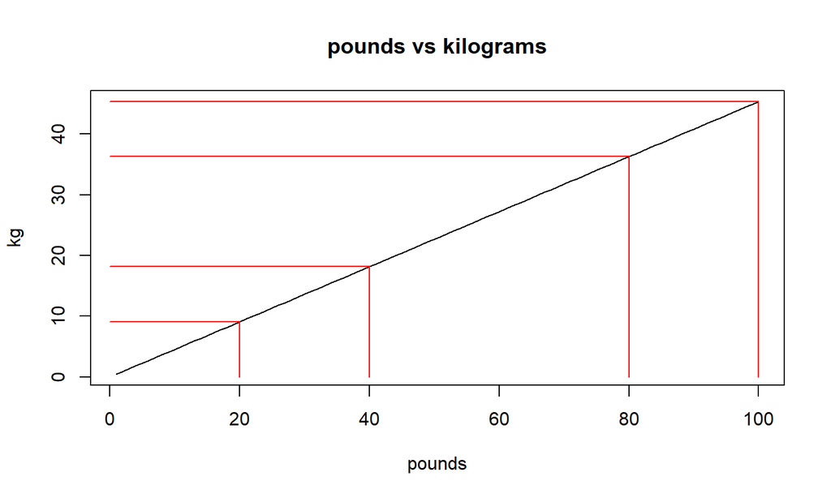

## Data Transformations

Sometimes a transformation is *non-linear*. A common non-linear transformation is the **log transformation**. A log transformation is the power we raise the constant \(e\) to get the original number. What power do we raise, or *exponentiate*, \(e\) to get 1000?

```r
log(1000)
```

```
## [1] 6.907755
```

Therefore, \(e^{6.907755} = 1000\). (The constant \(e\) is about 2.71828.) We can use the `exp()` function to perform this operation.

```r
exp(6.907755)
```

```
## [1] 999.9997
```

Close enough! The constant \(e\) is an irrational number, like \(\pi\), which means its decimals never end and never repeat. The details on how \(e\) is derived and why it is important go beyond the scope of these slides, but [read more](https://www.mathsisfun.com/numbers/e-eulers-number.html) if you like.

## The log transformation

Below is a plot of the values 1 - 500 and their log transformed values. Notice how the *distance* between 100 and 200, and 400 and 500, are *NOT the same within each scale*. The distance between 400 and 500 is smaller than the distance between 100 and 200 on the log scale. This is a *non-linear* transformation.

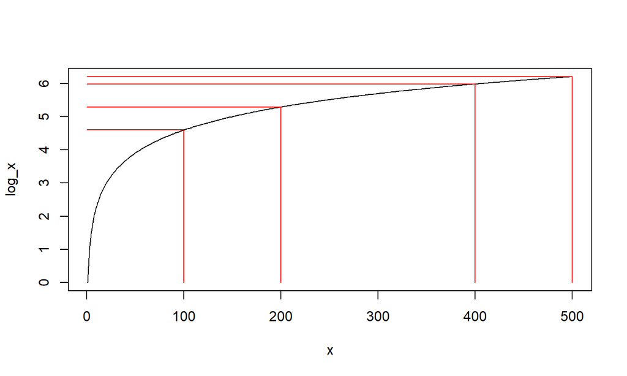

## The log transformation

The log transformation is sometimes useful for transforming skewed data to be more symmetric. This can help with statistical analyses. It spreads out values squished together and brings outlying values closer to the rest of the data.

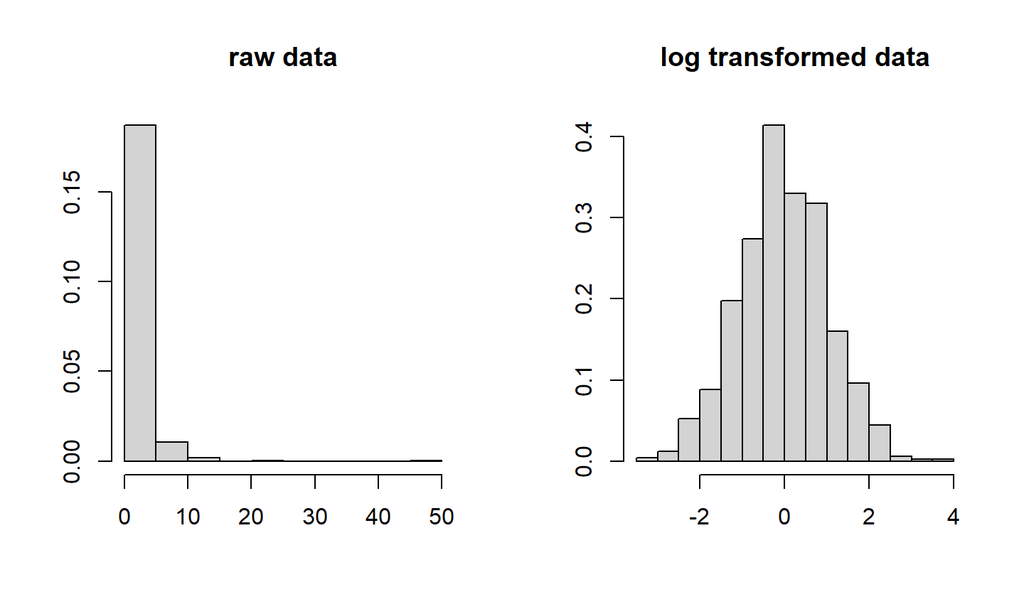

## Additive versus Multiplicative effects

If everyone in a company gets a $500 raise, then the effect is *additive*. Everyone had $500 added to their pay.

If everyone in a company gets a 5% raise, then the effect is *multiplicative*. Everyone had their pay *multiplied* by 1.05.

Multiplicative examples:

- Add 4% to 2000: \(2000 \times 1.04 = 2080\)
- Subtract 4% from 2000: \(2000 \times 0.96 = 1920\) (1 - 0.96 = 0.04)

## Indexing brackets in R

In R, we can use *indexing brackets* with a data frame to extract rows, columns, and values. Let’s make a toy data frame for demonstration.

```r
d <- data.frame(x = c(4,7,9), y = c("a","a","b"))
d
```

```
##   x y
## 1 4 a
## 2 7 a
## 3 9 b
```

Extract the value in row 3, column 2:

```r
d[3,2]
```

```
## [1] "b"
```

## Indexing brackets in R

Extract row 2 (notice we keep the comma):

```r
d[2,]
```

```
##   x y
## 2 7 a
```

## Indexing brackets in R

Extract column 2 (notice we keep the comma):

```r
d[,2]
```

```
## [1] "a" "a" "b"
```

Notice the result is a vector, not a data frame. If we want the result to remain a data frame, we add the argument `drop = FALSE`.

```r
d[,2, drop = FALSE]
```

```
##   y
## 1 a
## 2 a
## 3 b
```

## Data frames vs tibbles

That’s a difference between data frames and tibbles: tibbles always return data frames when using indexing brackets:

```r
d2 <- tibble::as_tibble(d)
d2[,2]
```

```
## # A tibble: 3 × 1
##   y
##   <chr>
## 1 a
## 2 a
## 3 b
```

Reminder: `tibble::as_tibble()` allows us to use the `as_tibble()` function without loading the tibble package.

## Indexing brackets in R

Finally, we can also use *double brackets* to extract columns from a data frame, which do not require a comma.

```r
d[[2]]
```

```
## [1] "a" "a" "b"
```

We can use the name of the column as well:

```r
d[["y"]]
```

```
## [1] "a" "a" "b"
```

Again, the result is a vector. Double brackets do not provide an argument for retaining the data frame structure.